# Automatic Translation of *TensorFlow* to VTA, via TVM

Original author: David Banas david@luminouscomputing.com  
Original date: June 28, 2019

Copyright © 2019 Luminous Computing, Inc.; all rights reserved World-wide.

This Jupyter notebook provides a very simple example of automatically translating a TensorFlow design, via TVM, to a VTA-based implementation. The intent is that it serve as the starting point for a pre-sales high-level behavioral simulator of our *V1* device. Such a simulator would help our sales staff engage with potential customers and quickly assess power/performance metrics for a particular ML design.

My intent here is to:

1. Construct a *TensorFlow* design of a 32x32 matrix-vector multiplier (MVM).
2. Import that design into TVM automatically.
3. Compile the design to VTA, which uses a 16-element accumulator by default.

## *TensorFlow* Design of 32x32 Matrix-Vector Multiplier

Here, I construct a 32x32 MVM, using *TensorFlow*. This will serve as the initial input for TVM compilation. The calculation I'm attempting to build is:

$$ \begin{bmatrix} y_0 \\ y_1 \\ \vdots \\ y_{31} \end{bmatrix} = \begin{bmatrix} w_{0,0} & w_{0,1} & ... & w_{0,31} \\ w_{1,0} & w_{1,1} & ... & w_{1,31} \\ \vdots & \ddots & \ddots & \vdots \\ w_{31,0} & w_{31,1} & ... & w_{31,31} \end{bmatrix} \begin{bmatrix} x_0 \\ x_1 \\ \vdots \\ x_{31} \end{bmatrix} $$

where $y_n = \vec{w_n} \cdot \vec{x} = \sum_i w_{n,i} x_i$.

```python
import numpy      as np
import tensorflow as tf

# Define the size of the matrix/vectors.
N = 32

# Create the specification, using NumPy.
W = np.random.rand(N,N)
x = np.random.rand(N,)
y = np.dot(W, x)  # This vector serves as the specification for correct computation output, throughout.

# Create the TensorFlow equivalent design.
Wp  = tf.placeholder(tf.float64, shape=(N,N), name='W')
xp  = tf.placeholder(tf.float64, shape=(N,),  name='x')
mvm = tf.tensordot(Wp, xp, axes=1, name='MVM')

# Run a TensorFlow session, checking the result against the specification and generating the graph.
with tf.Session() as session:
    result        = session.run(mvm, feed_dict={Wp: W, xp: x})
    graphTF       = session.graph                                           # TensorFlow graph.
    writer        = tf.summary.FileWriter("./logs/mvm", graphTF)
try:
    assert np.isclose(result, y).all()  # `np.isclose()` is (==) for floating point.
except:
    print("y =")
    print(y)
    print("result =")
    print(result)
    raise

print("Success!")
```

```
Success!
```

Then, executing: `tensorboard --logdir=logs` at a command prompt launches *TensorBoard* at: http://localhost:6006  
From there I see this:

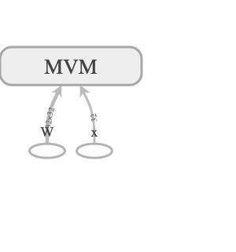

## Import to NNVM (Old TVM IR)

Now that we have a *TensorFlow* design that is meeting its specification, let's import it into TVM, via NNVM...

**Note:** I'm using *NNVM*, as opposed to *Relay*, because I suspect NNVM offers an automated compilation path towards VTA-based implementation, which Relay does not.

```python
import time

import tvm
import nnvm.compiler
import vta
import vta.testing
from tvm         import rpc, autotvm
from tvm.contrib import graph_runtime, util

device="vta"

# Load VTA parameters from the vta/config/vta_config.json file
env = vta.get_env()

# Set VTA simulation target.
remote = rpc.LocalSession()

# Global IRs
ir1 = None
ir2 = None
ir3 = None
ir4 = None

def tf2NNVM(graphTF, device="vta", target_host="llvm",
            shape_dict = {"W": (32, 32),  "x": (32,)},
            dtype_dict = {"W": 'float64', "x": 'float64'}):
    """ Convert a TensorFlow graph into a NNVM graph.

    Args:
        graphTF(GraphDef): TensorFlow graph.

        device(str): Target device identification string. (Optional; default = "vta")

        target_host(str): Target host identification string. (Optional; default = "llvm")

        shape_dict(dict): Input shapes. (Optional; default = {"W": (32, 32),  "x": (32,)})

        dtype_dict(dict): Input data type. (Optional; default = {"W": 'float64', "x": 'float64'})

    Returns:
        graph(nnvm.graph.Graph): The compiled/optimized graph.

        lib(tvm.module.Module): The compiled/optimized object.

        params(dict): The module parameters.
    """
    global ir1, ir2, ir3, ir4

    # Measure build start time
    build_start = time.time()

    # Derive the TVM target
    target = tvm.target.create("llvm -device={}".format(device))

    # Load the TensorFlow graph into NNVM.
    sym, params = nnvm.frontend.from_tensorflow(graphTF.as_graph_def())
    graph = nnvm.graph.create(sym)
    ir1 = graph.ir()

    # Populate the shape and data type dictionary
    shape_dict.update({k: v.shape for k, v in params.items()})
    dtype_dict.update({k: str(v.dtype) for k, v in params.items()})

    # Apply NNVM graph optimization passes, targeting VTA back-end.
    graph = vta.graph.clean_cast(graph)
    ir2 = graph.ir()
    graph = vta.graph.clean_conv_fuse(graph)
    ir3 = graph.ir()
    if target.device_name == "vta":
        print("I'm here.")
        assert env.BLOCK_IN == env.BLOCK_OUT
        print("shape_dict:", shape_dict)
        print("BATCH:", env.BATCH)
        print("BLOCK_OUT:", env.BLOCK_OUT)
        graph = vta.graph.pack(graph, shape_dict, env.BATCH, env.BLOCK_OUT)
    ir4 = graph.ir()

    # Compile NNVM graph
    with nnvm.compiler.build_config(opt_level=3):
        if target.device_name != "vta":
            graph, lib, params = nnvm.compiler.build(
                graph, target, shape_dict, dtype_dict,
                params=params, target_host=target_host)
        else:
            with vta.build_config():
                graph, lib, params = nnvm.compiler.build(
                    graph, target, shape_dict, dtype_dict,
                    params=params, target_host=target_host)

    # Save the compiled inference graph library
    assert tvm.module.enabled("rpc")
    temp = util.tempdir()
    lib.save(temp.relpath("graphlib.o"))

    # Send the inference library over to the remote RPC server
    remote.upload(temp.relpath("graphlib.o"))
    lib = remote.load_module("graphlib.o")

    # Measure build time
    build_time = time.time() - build_start
    print("Inference graph built in {0:.2f}s!".format(build_time))

    return graph, lib, params

# Device context
ctx = remote.ext_dev(0) if device == "vta" else remote.cpu(0)

# Build the graph runtime
graph, lib, params = tf2NNVM(graphTF)
m = graph_runtime.create(graph, lib, ctx)

# Set the parameters
m.set_input(**params)
```

```
I'm here.
shape_dict: {'W': (32, 32), 'x': (32,), 'MVM/transpose/perm': (2,), 'MVM/transpose_1/perm': (1,)}
BATCH: 1
BLOCK_OUT:
```

```
WARNING:autotvm:Cannot find config for target=llvm -device=vta, workload=('dense', (32, 32, 'float64'), (1, 32, 'float64'), 0, 0). A fallback configuration is used, which may bring great performance regression.
```

```
 16
Inference graph built in 0.26s!
```

## Test the Imported Graph

Now, run the NNVM version of the graph, testing its correctness against the original NumPy specification.

```python
m.set_input('W', W)
m.set_input('x', x)

# Perform calculation.
timer = m.module.time_evaluator("run", ctx, number=1)
tcost = timer()

# Get result and compare against specification.
yp = m.get_output(0).asnumpy()
try:
    assert (np.isclose(yp, y)).all()  # handy floating point equivalent of (==)
except:
    print("tvm_output:", yp)
    print("y:", y)
    print("Error: {:5.2f}%".format(np.sqrt(sum((yp - y)**2)/sum(y**2))))
    raise

print("Success!")
```

```
Success!
```

## Inspecting the Graph at Different Points in the Compilation Flow

In this section we peek at the computation graph at different points in the compilation/optimization flow. We'll try and convince ourselves that things look correct, based upon our expectations of how a 32x32 MVM would need to be broken down, in order to make use of a 16x16 MVM engine, which is what I believe we get from the VTA in its default configuration.

The end goal here is to achieve confidence that this flow will do the right thing, when we ask it to decompose some arbitrary customer *TensorFlow* design, in order to implement it on our *V1* chip.

### After the call to `nnvm.frontend.from_tensorflow()` and `nnvm.graph.create()`

Here, we're looking at the graph immediately after importing it from *TensorFlow*.

```python
print(ir1)
```

```
Graph(%W, %x) {
  %1 = transpose(%W, axes='(0, 1)')
  %2 = reshape(%1, shape='(32, 32)')
  %4 = transpose(%x, axes='(0,)')
  %5 = reshape(%4, shape='(32, 1)')
  %6 = transpose(%5, axes='(1, 0)')
  %7 = dense(%2, %6, units='1', use_bias='False')
  %8 = reshape(%7, shape='(32,)')
  ret %8
}
```

Okay, this looks good. I assume that `dense()` is just a fully-connected normal matrix-vector multiplication. I don't know why it thinks that transpositions are necessary, but whatever.

### After the call to `vta.graph.clean_cast()`

This appears to have been a null transform, as the graph appears unchanged from the previous step. My guess (based entirely on the function name) is this step cleans up data type mismatches and we had none.

```python
print(ir2)
```

```
Graph(%W, %x) {
  %1 = transpose(%W, axes='(0, 1)')
  %2 = reshape(%1, shape='(32, 32)')
  %4 = transpose(%x, axes='(0,)')
  %5 = reshape(%4, shape='(32, 1)')
  %6 = transpose(%5, axes='(1, 0)')
  %7 = dense(%2, %6, use_bias='False', units='1')
  %8 = reshape(%7, shape='(32,)')
  ret %8
}
```

### After the call to `vta.graph.clean_conv_fuse()`

Hmmm, another null transform? I'm starting to get a little suspicious. Although, the function name does suggest that it applies only to *convolutional* layers, and this is a *fully connected* network. So, perhaps, all is well.

```python
print(ir3)
```

```
Graph(%W, %x) {
  %1 = transpose(%W, axes='(0, 1)')
  %2 = reshape(%1, shape='(32, 32)')
  %4 = transpose(%x, axes='(0,)')
  %5 = reshape(%4, shape='(32, 1)')
  %6 = transpose(%5, axes='(1, 0)')
  %7 = dense(%2, %6, use_bias='False', units='1')
  %8 = reshape(%7, shape='(32,)')
  ret %8
}
```

### After the call to `vta.graph.pack()`

```python
print(ir4)
```

```
Graph(%W, %x) {
  %1 = transpose(%W, axes='(0, 1)')
  %2 = reshape(%1, shape='(32, 32)')
  %4 = transpose(%x, axes='(0,)')
  %5 = reshape(%4, shape='(32, 1)')
  %6 = transpose(%5, axes='(1, 0)')
  %7 = dense(%2, %6, use_bias='False', units='1')
  %8 = reshape(%7, shape='(32,)')
  ret %8
}
graph_attr_keys = [shape_num_unknown_nodes, shape]
```

Okay, this I don't understand. This is the step at which I expected the computation to be "broken down", in order to fit on the 16x16 MVM engine, which I believe to be what the VTA offers us in its default configuration. The last line of output (`graph_attr_keys ...`) makes it clear that we are *not* simply getting the same graph as in the previous step. However, just to be absolutely certain that the body of the `if(...` statement in the code above is being entered, I added the debugging line:

```
print("I'm here.")
```

The if body *is* getting entered. So, what's going on?!

Well, my assumption about what to expect from this function is based solely on its name, which isn't very good engineering practice. :(  
Let's see what its docstring says...

```python
from IPython.display import display, Markdown, Latex

display(Markdown(vta.graph.pack.__doc__))
```

Pack the graph into batch&channel packed format.

```
Parameters
----------
graph : Graph
   The input graph.

shape_dict : dict of str to shapex
   The input shape.

bfactor : int
   The packing factor in batch

cfactor : int
   The packing factor in channel

start_name: str, optional
   Start name start packing from certain known node.

Returns
-------
graph : Graph
    The transformed graph.
```

Hmmm, it sure sounds like what I expected. What the Hell?!

Just to confirm my assumptions about the default VTA capabilities, I added the following additional debugging code to the `if` body:

```
print("shape_dict:", shape_dict)
print("BATCH:", env.BATCH)
print("BLOCK_OUT:", env.BLOCK_OUT)
```

and got this response (See code block above.):

```
shape_dict: {'W': (32, 32), 'x': (32,), 'MVM/transpose/perm': (2,), 'MVM/transpose_1/perm': (1,)}
BATCH: 1
BLOCK_OUT: 16
```

which seems to confirm my assumption, re: a 16x16 MVM. I'm stumped. :(

### After the call to `nnvm.compiler.build()`

Here is the graph after the final transformation in the stack. As can be seen, it takes on quite a different character at this point. I'm not sure why.

```python
print(graph.ir())
```

```
Graph(%W, %x) {
  %1 = tvm_op(%W, num_outputs='1', num_inputs='1', func_name='fuse_transpose_reshape', flatten_data='0')
  %3 = tvm_op(%x, num_outputs='1', num_inputs='1', func_name='fuse_transpose_reshape_transpose', flatten_data='0')
  %4 = tvm_op(%1, %3, num_outputs='1', num_inputs='2', func_name='fuse_dense', flatten_data='0')
  %5 = tvm_op(%4, num_outputs='1', num_inputs='1', func_name='fuse_reshape', flatten_data='0')
  ret %5
}
graph_attr_keys = [storage_id, shape, dtype, dltype]
```

## Appendix A - Docs & Sample Output From Some Interesting Functions

In perusing these tutorials, several functions have caught my eye. I wanted to better understand these functions. So, here, I print out their doc-strings and, in some cases, generate sample output.

### `util.tempdir()`

```python
print(util.tempdir.__doc__)
temp = util.tempdir()
print(temp.relpath("dummy"))
```

```
Create temp dir which deletes the contents when exit.

    Returns
    -------
    temp : TempDirectory
        The temp directory object

/var/folders/43/ys_4mp490r348rgc9xrwzn400000gn/T/tmpl59f0j70/dummy
```

### `tensorflow.tensordot()`

```python
from IPython.display import display, Markdown, Latex

display(Markdown(tf.tensordot.__doc__))
```

Tensor contraction of a and b along specified axes.

Tensordot (also known as tensor contraction) sums the product of elements from `a` and `b` over the indices specified by `a_axes` and `b_axes`. The lists `a_axes` and `b_axes` specify those pairs of axes along which to contract the tensors. The axis `a_axes[i]` of `a` must have the same dimension as axis `b_axes[i]` of `b` for all `i` in `range(0, len(a_axes))`. The lists `a_axes` and `b_axes` must have identical length and consist of unique integers that specify valid axes for each of the tensors.

This operation corresponds to `numpy.tensordot(a, b, axes)`.

Example 1: When `a` and `b` are matrices (order 2), the case `axes = 1` is equivalent to matrix multiplication.

Example 2: When `a` and `b` are matrices (order 2), the case `axes = [[1], [0]]` is equivalent to matrix multiplication.

Example 3: Suppose that $a_{ijk}$ and $b_{lmn}$ represent two tensors of order 3. Then, `contract(a, b, [[0], [2]])` is the order 4 tensor $c_{jklm}$ whose entry corresponding to the indices $(j,k,l,m)$ is given by:

$ c_{jklm} = \sum_i a_{ijk} b_{lmi} $.

In general, `order(c) = order(a) + order(b) - 2*len(axes[0])`.

Args: a: `Tensor` of type `float32` or `float64`. b: `Tensor` with the same type as `a`. axes: Either a scalar `N`, or a list or an `int32` `Tensor` of shape [2, k]. If axes is a scalar, sum over the last N axes of a and the first N axes of b in order. If axes is a list or `Tensor` the first and second row contain the set of unique integers specifying axes along which the contraction is computed, for `a` and `b`, respectively. The number of axes for `a` and `b` must be equal. name: A name for the operation (optional).

Returns: A `Tensor` with the same type as `a`.

Raises: ValueError: If the shapes of `a`, `b`, and `axes` are incompatible. IndexError: If the values in axes exceed the rank of the corresponding tensor.

### `tensorflow.placeholder()`

```python
display(Markdown(tf.placeholder.__doc__))
```

Inserts a placeholder for a tensor that will be always fed.

**Important**: This tensor will produce an error if evaluated. Its value must be fed using the `feed_dict` optional argument to `Session.run()`, `Tensor.eval()`, or `Operation.run()`.

For example:

```
x = tf.placeholder(tf.float32, shape=(1024, 1024))
  y = tf.matmul(x, x)

  with tf.Session() as sess:
    print(sess.run(y))  # ERROR: will fail because x was not fed.

    rand_array = np.random.rand(1024, 1024)
    print(sess.run(y, feed_dict={x: rand_array}))  # Will succeed.
```

@compatibility(eager) Placeholders are not compatible with eager execution. @end_compatibility

Args: dtype: The type of elements in the tensor to be fed. shape: The shape of the tensor to be fed (optional). If the shape is not specified, you can feed a tensor of any shape. name: A name for the operation (optional).

Returns: A `Tensor` that may be used as a handle for feeding a value, but not evaluated directly.

Raises: RuntimeError: if eager execution is enabled

### `nnvm.frontend.from_tensorflow()`

```python
display(Markdown(nnvm.frontend.from_tensorflow.__doc__))
```

Load tensorflow graph which is a python tensorflow graph object into nnvm graph. The companion parameters will be handled automatically.

```
Parameters
----------
graph : GraphDef object
    Tensorflow GraphDef

layout : target layout to be used (Optional)
    NCHW only supported now to enable NHWC models on GPU.

shape : Dictionary of input dimensions (Optional)
    Graph level input shape dictionary.

outputs : List of output tensor names (Optional)
    if not specified then the last node is assumed as graph output.

Returns
-------
sym : nnvm.Symbol
    Compatible nnvm symbol

params : dict of str to tvm.ndarray
    Dict of converted parameters stored in tvm.ndarray format
```

### `vta.graph.pack()`

```python
display(Markdown(vta.graph.pack.__doc__))
```

Pack the graph into batch&channel packed format.

```
Parameters
----------
graph : Graph
   The input graph.

shape_dict : dict of str to shapex
   The input shape.

bfactor : int
   The packing factor in batch

cfactor : int
   The packing factor in channel

start_name: str, optional
   Start name start packing from certain known node.

Returns
-------
graph : Graph
    The transformed graph.
```